# Annexes : Plot And Explain

```r
library(NantesStatisticalAnalysis)
```

```r
data <- t(read.csv(file="dataset.csv", header=FALSE, sep=","))
```

Comment interprétrer une boite à moustaches : –> la boite est délimitée par le premier et neuvième décile de la variable étudiée, ainsi cela nous permet de détecter des valeurs extrêmes (outliers) qui tireraient la distribution. –> les deux extrémités de la boite représente le premier et troisième quartile, par rapport à la médiane, la barre centrale. Cela nous permet d’interpréter la répartition des valeurs étudiées (savoir si la répartition se veut plus centrée, tirée d’un côté ou l’autre)

Comment interpréter l’histogramme : –> on doit retrouver la même tendance que dans la boite à moustache. –> On remarque très vite la répartition des données, certaines sont centrées et ont donc des valeurs symétriques, d’autre prenne une forme qui s’apparente plus à une distribution du Chi-square (qui tire vers la droite …).

(Ici on se limitera au 40 première variables pour des raisons évidentes de tailles des annexes)

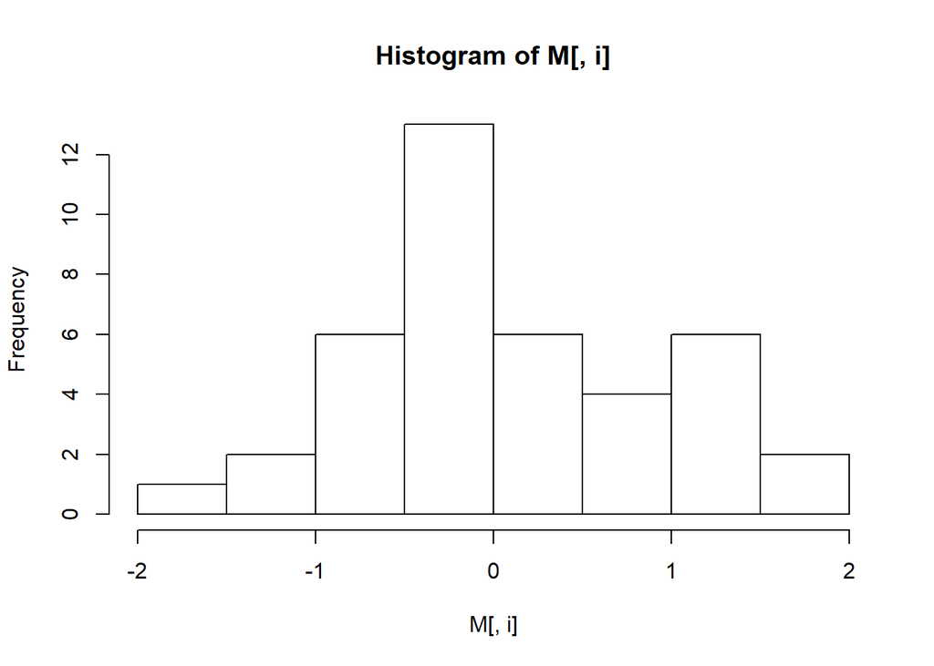

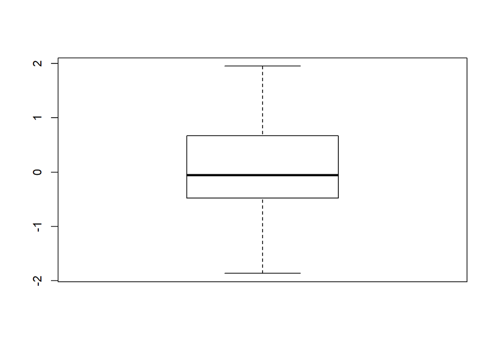

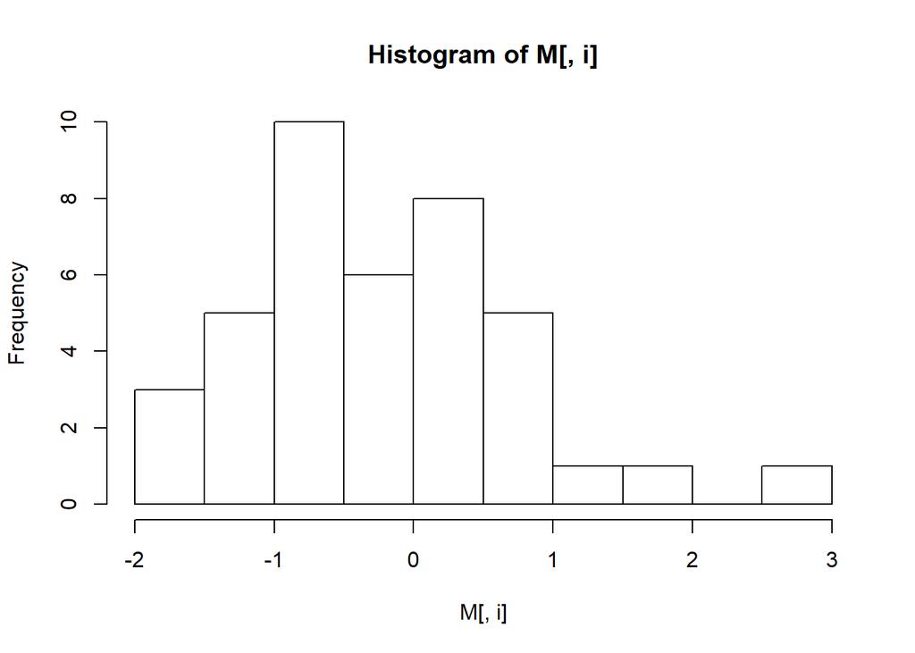

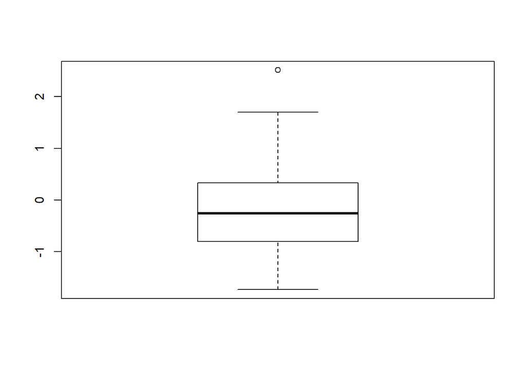

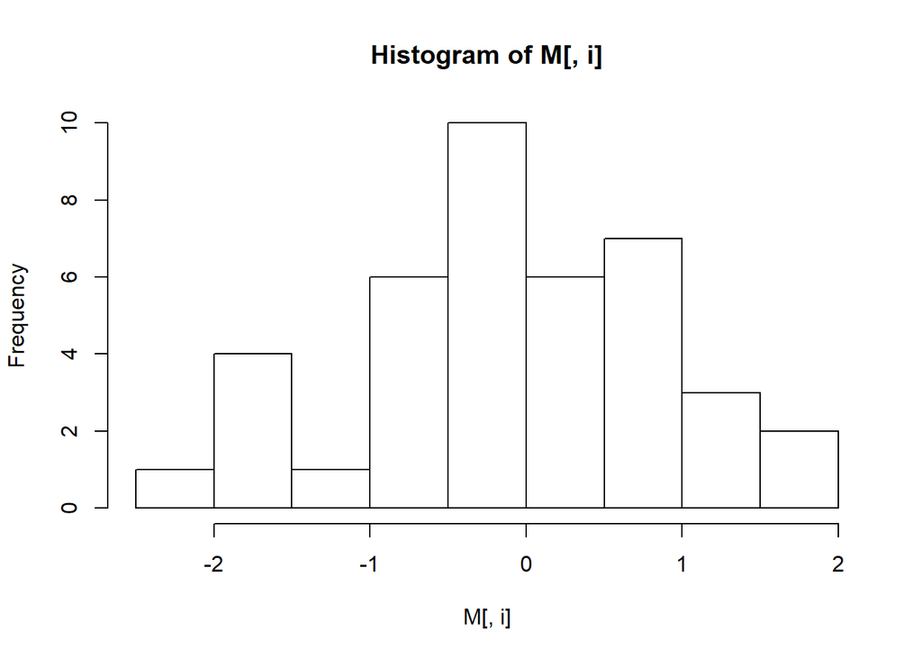

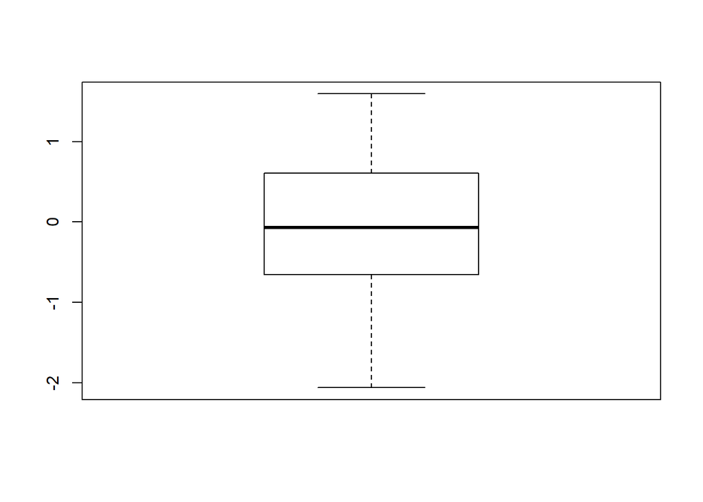

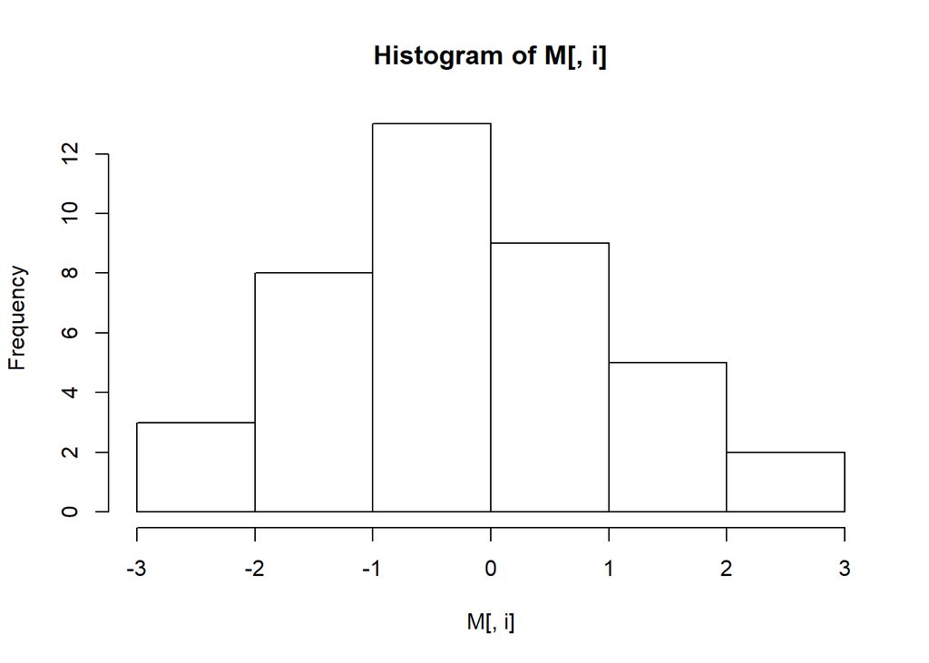

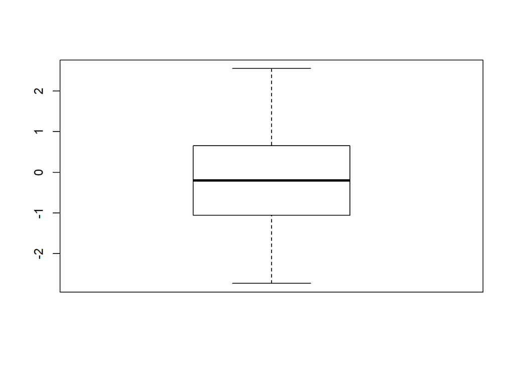

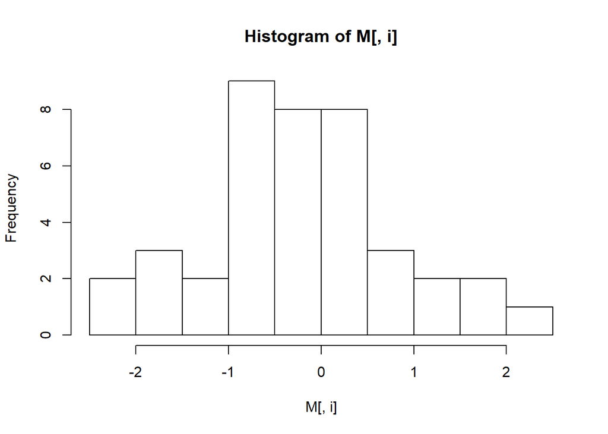

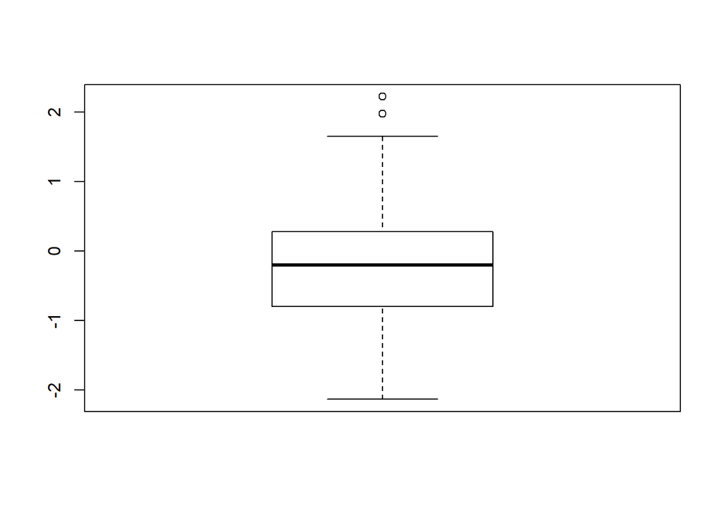

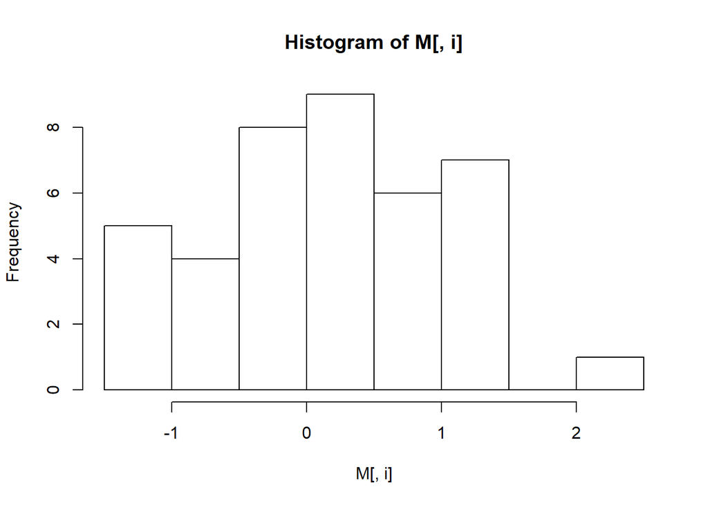

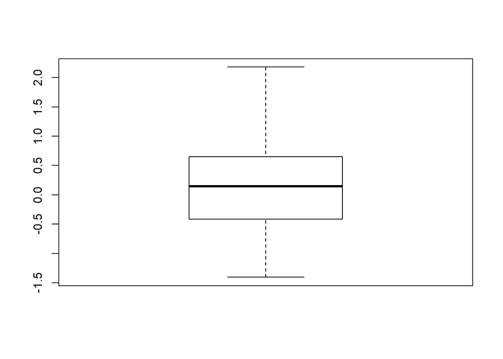

[68 more figures not shown]

```
## [1] "# ------------------------ # Comparison of position # ------------------------ # "
## v 1  :
##     mean :  0.0922434
##    median :  -0.05973598
##    mode :  numeric
##    Comparison between mean and median :  Outliers detectedNULL
## [1] "------------------------"
## v 2  :
##     mean :  -0.2064043
##    median :  -0.2543572
##    mode :  numeric
##    Comparison between mean and median :  Outliers detectedNULL
## [1] "------------------------"
## v 3  :
##     mean :  -0.05350774
##    median :  -0.06776417
##    mode :  numeric
##    Comparison between mean and median :  Outliers detectedNULL
## [1] "------------------------"
## v 4  :
##     mean :  -0.1263033
##    median :  -0.199703
##    mode :  numeric
##    Comparison between mean and median :  Outliers detectedNULL
## [1] "------------------------"
## v 5  :
##     mean :  -0.183271
##    median :  -0.2038343
##    mode :  numeric
##    Comparison between mean and median :  Outliers detectedNULL
## [1] "------------------------"
## v 6  :
##     mean :  0.1205776
##    median :  0.1475267
##    mode :  numeric
##    Comparison between mean and median :  Not centred but no outliersNULL
## [1] "------------------------"
## v 7  :
##     mean :  -0.1521483
##    median :  -0.1613708
```

[output cut: 628 more lines]

```
##    skewness rate :  -0.1456429
##    interpretation :  Converging to the left DistributionNULL
## [1] "------------------------"
## v 39  :
##     kurtosis rate :  -0.4557405
##    interpretation :  more flattened gauss distribution
##    skewness rate :  0.493499
##    interpretation :  Converging to the right DistributionNULL
## [1] "------------------------"
## v 40  :
##     kurtosis rate :  0.3954447
##    interpretation :  more concentrated than Gauss
##    skewness rate :  -0.2380239
##    interpretation :  Converging to the left DistributionNULL
## [1] "------------------------"
```

```r
explainDataset(data[,1:40], c(1:40))
```

On remarque que sur la globalité, il y a beaucoup de valeurs extrêmes qui ont tendance à tirer les répartitions. On ne trouve que très peu de répartition centrée. On en déduit ainsi que les variables (gènes) sont très dépendantes de chaque individu, certes ont retrouve tout de même un intervale commun entre le premier et le troisième quartile, mais en dehors, il y a souvent des valeurs extrêmes.

Interprétation du Chi-deux : –> Plus le X-square est élevé plus les variables sont fortement corrélées entre elles et inversement. En dessous d’un certain seuil de la p-value, on peut alors rejeté l’indépendance des deux variables.

Interprétation de la régression linéaire : –> visuellement, si la droite correspond bien à l’étalement des données, on suppose que les variables sont corréllées

```r
explainDataset(data[,1:40], c(1:40), T)
```

```
## [1] "# ------------------------ # X2 # ------------------------ # "
```

```
##
##  Chi-squared test for given probabilities
##
## data:  newM
## X-squared = 17.469, df = 39, p-value = 0.9989
##
## [1] "Variables[1,2], Considérons un seuil à 0.05, on peut alors rejeter l'hypothèse nulle d'indépendance"
## [1] "------------------------"
```

```
##
##  Chi-squared test for given probabilities
##
## data:  newM
## X-squared = 18.158, df = 39, p-value = 0.9982
##
## [1] "Variables[2,3], Considérons un seuil à 0.05, on peut alors rejeter l'hypothèse nulle d'indépendance"
## [1] "------------------------"
```

```
##
##  Chi-squared test for given probabilities
##
## data:  newM
## X-squared = 22.099, df = 39, p-value = 0.9866
##
## [1] "Variables[3,4], Considérons un seuil à 0.05, on peut alors rejeter l'hypothèse nulle d'indépendance"
## [1] "------------------------"
```

```
##
##  Chi-squared test for given probabilities
##
## data:  newM
## X-squared = 20.217, df = 39, p-value = 0.9944
##
## [1] "Variables[4,5], Considérons un seuil à 0.05, on peut alors rejeter l'hypothèse nulle d'indépendance"
## [1] "------------------------"
```

```
##
##  Chi-squared test for given probabilities
##
## data:  newM
## X-squared = 14.006, df = 39, p-value = 0.9999
##
## [1] "Variables[5,6], Considérons un seuil à 0.05, on peut alors rejeter l'hypothèse nulle d'indépendance"
## [1] "------------------------"
```

```
##
##  Chi-squared test for given probabilities
##
## data:  newM
## X-squared = 19.094, df = 39, p-value = 0.9969
##
## [1] "Variables[6,7], Considérons un seuil à 0.05, on peut alors rejeter l'hypothèse nulle d'indépendance"
## [1] "------------------------"
```

```
##
##  Chi-squared test for given probabilities
##
## data:  newM
## X-squared = 14.242, df = 39, p-value = 0.9999
##
## [1] "Variables[7,8], Considérons un seuil à 0.05, on peut alors rejeter l'hypothèse nulle d'indépendance"
## [1] "------------------------"
```

```
##
##  Chi-squared test for given probabilities
##
## data:  newM
## X-squared = 13.229, df = 39, p-value = 1
##
## [1] "Variables[8,9], Considérons un seuil à 0.05, on peut alors rejeter l'hypothèse nulle d'indépendance"
## [1] "------------------------"
```

```
##
##  Chi-squared test for given probabilities
##
## data:  newM
## X-squared = 15.111, df = 39, p-value = 0.9998
##
## [1] "Variables[9,10], Considérons un seuil à 0.05, on peut alors rejeter l'hypothèse nulle d'indépendance"
## [1] "------------------------"
```

```
##
##  Chi-squared test for given probabilities
##
## data:  newM
## X-squared = 27.06, df = 39, p-value = 0.9256
##
## [1] "Variables[10,11], Considérons un seuil à 0.05, on peut alors rejeter l'hypothèse nulle d'indépendance"
## [1] "------------------------"
```

```
##
##  Chi-squared test for given probabilities
##
## data:  newM
## X-squared = 33.754, df = 39, p-value = 0.7076
##
## [1] "Variables[11,12], Considérons un seuil à 0.05, on peut alors rejeter l'hypothèse nulle d'indépendance"
## [1] "------------------------"
```

```
##
##  Chi-squared test for given probabilities
##
## data:  newM
## X-squared = 27.3, df = 39, p-value = 0.9206
##
## [1] "Variables[12,13], Considérons un seuil à 0.05, on peut alors rejeter l'hypothèse nulle d'indépendance"
## [1] "------------------------"
```

```
##
##  Chi-squared test for given probabilities
##
## data:  newM
## X-squared = 27.443, df = 39, p-value = 0.9175
##
## [1] "Variables[13,14], Considérons un seuil à 0.05, on peut alors rejeter l'hypothèse nulle d'indépendance"
## [1] "------------------------"
```

```
##
##  Chi-squared test for given probabilities
##
## data:  newM
## X-squared = 29.656, df = 39, p-value = 0.8598
##
## [1] "Variables[14,15], Considérons un seuil à 0.05, on peut alors rejeter l'hypothèse nulle d'indépendance"
## [1] "------------------------"
```

```
##
##  Chi-squared test for given probabilities
##
## data:  newM
## X-squared = 34.036, df = 39, p-value = 0.6955
##
## [1] "Variables[15,16], Considérons un seuil à 0.05, on peut alors rejeter l'hypothèse nulle d'indépendance"
## [1] "------------------------"
```

```
##
##  Chi-squared test for given probabilities
##
## data:  newM
## X-squared = 31.048, df = 39, p-value = 0.8141
##
## [1] "Variables[16,17], Considérons un seuil à 0.05, on peut alors rejeter l'hypothèse nulle d'indépendance"
## [1] "------------------------"
```

```
##
##  Chi-squared test for given probabilities
##
## data:  newM
## X-squared = 24.253, df = 39, p-value = 0.969
##
## [1] "Variables[17,18], Considérons un seuil à 0.05, on peut alors rejeter l'hypothèse nulle d'indépendance"
## [1] "------------------------"
```

```
##
##  Chi-squared test for given probabilities
##
## data:  newM
## X-squared = 22.802, df = 39, p-value = 0.982
##
## [1] "Variables[18,19], Considérons un seuil à 0.05, on peut alors rejeter l'hypothèse nulle d'indépendance"
## [1] "------------------------"
```

```
##
##  Chi-squared test for given probabilities
##
## data:  newM
## X-squared = 28.658, df = 39, p-value = 0.8882
##
## [1] "Variables[19,20], Considérons un seuil à 0.05, on peut alors rejeter l'hypothèse nulle d'indépendance"
## [1] "------------------------"
```

```
##
##  Chi-squared test for given probabilities
##
## data:  newM
## X-squared = 14.341, df = 39, p-value = 0.9999
##
## [1] "Variables[20,21], Considérons un seuil à 0.05, on peut alors rejeter l'hypothèse nulle d'indépendance"
## [1] "------------------------"
```

```
##
##  Chi-squared test for given probabilities
##
## data:  newM
## X-squared = 16.53, df = 39, p-value = 0.9994
##
## [1] "Variables[21,22], Considérons un seuil à 0.05, on peut alors rejeter l'hypothèse nulle d'indépendance"
## [1] "------------------------"
```

```
##
##  Chi-squared test for given probabilities
##
## data:  newM
## X-squared = 15.928, df = 39, p-value = 0.9996
##
## [1] "Variables[22,23], Considérons un seuil à 0.05, on peut alors rejeter l'hypothèse nulle d'indépendance"
## [1] "------------------------"
```

```
##
##  Chi-squared test for given probabilities
##
## data:  newM
## X-squared = 26.053, df = 39, p-value = 0.9442
##
## [1] "Variables[23,24], Considérons un seuil à 0.05, on peut alors rejeter l'hypothèse nulle d'indépendance"
## [1] "------------------------"
```

```
##
##  Chi-squared test for given probabilities
##
## data:  newM
## X-squared = 24.076, df = 39, p-value = 0.9708
##
## [1] "Variables[24,25], Considérons un seuil à 0.05, on peut alors rejeter l'hypothèse nulle d'indépendance"
## [1] "------------------------"
```

```
##
##  Chi-squared test for given probabilities
##
## data:  newM
## X-squared = 14.658, df = 39, p-value = 0.9999
##
## [1] "Variables[25,26], Considérons un seuil à 0.05, on peut alors rejeter l'hypothèse nulle d'indépendance"
## [1] "------------------------"
```

```
##
##  Chi-squared test for given probabilities
##
## data:  newM
## X-squared = 15.693, df = 39, p-value = 0.9997
##
## [1] "Variables[26,27], Considérons un seuil à 0.05, on peut alors rejeter l'hypothèse nulle d'indépendance"
## [1] "------------------------"
```

```
##
##  Chi-squared test for given probabilities
##
## data:  newM
## X-squared = 14.662, df = 39, p-value = 0.9999
##
## [1] "Variables[27,28], Considérons un seuil à 0.05, on peut alors rejeter l'hypothèse nulle d'indépendance"
## [1] "------------------------"
```

```
##
##  Chi-squared test for given probabilities
##
## data:  newM
## X-squared = 16.914, df = 39, p-value = 0.9992
##
## [1] "Variables[28,29], Considérons un seuil à 0.05, on peut alors rejeter l'hypothèse nulle d'indépendance"
## [1] "------------------------"
```

```
##
##  Chi-squared test for given probabilities
##
## data:  newM
## X-squared = 13.886, df = 39, p-value = 0.9999
##
## [1] "Variables[29,30], Considérons un seuil à 0.05, on peut alors rejeter l'hypothèse nulle d'indépendance"
## [1] "------------------------"
```

```
##
##  Chi-squared test for given probabilities
##
## data:  newM
## X-squared = 16.47, df = 39, p-value = 0.9994
##
## [1] "Variables[30,31], Considérons un seuil à 0.05, on peut alors rejeter l'hypothèse nulle d'indépendance"
## [1] "------------------------"
```

```
##
##  Chi-squared test for given probabilities
##
## data:  newM
## X-squared = 16.043, df = 39, p-value = 0.9996
##
## [1] "Variables[31,32], Considérons un seuil à 0.05, on peut alors rejeter l'hypothèse nulle d'indépendance"
## [1] "------------------------"
```

```
##
##  Chi-squared test for given probabilities
##
## data:  newM
## X-squared = 16.708, df = 39, p-value = 0.9993
##
## [1] "Variables[32,33], Considérons un seuil à 0.05, on peut alors rejeter l'hypothèse nulle d'indépendance"
## [1] "------------------------"
```

```
##
##  Chi-squared test for given probabilities
##
## data:  newM
## X-squared = 16.225, df = 39, p-value = 0.9995
##
## [1] "Variables[33,34], Considérons un seuil à 0.05, on peut alors rejeter l'hypothèse nulle d'indépendance"
## [1] "------------------------"
```

```
##
##  Chi-squared test for given probabilities
##
## data:  newM
## X-squared = 11.303, df = 39, p-value = 1
##
## [1] "Variables[34,35], Considérons un seuil à 0.05, on peut alors rejeter l'hypothèse nulle d'indépendance"
## [1] "------------------------"
```

```
##
##  Chi-squared test for given probabilities
##
## data:  newM
## X-squared = 11.067, df = 39, p-value = 1
##
## [1] "Variables[35,36], Considérons un seuil à 0.05, on peut alors rejeter l'hypothèse nulle d'indépendance"
## [1] "------------------------"
```

```
##
##  Chi-squared test for given probabilities
##
## data:  newM
## X-squared = 14.102, df = 39, p-value = 0.9999
##
## [1] "Variables[36,37], Considérons un seuil à 0.05, on peut alors rejeter l'hypothèse nulle d'indépendance"
## [1] "------------------------"
```

```
##
##  Chi-squared test for given probabilities
##
## data:  newM
## X-squared = 16.061, df = 39, p-value = 0.9996
##
## [1] "Variables[37,38], Considérons un seuil à 0.05, on peut alors rejeter l'hypothèse nulle d'indépendance"
## [1] "------------------------"
```

```
##
##  Chi-squared test for given probabilities
##
## data:  newM
## X-squared = 20.343, df = 39, p-value = 0.994
##
## [1] "Variables[38,39], Considérons un seuil à 0.05, on peut alors rejeter l'hypothèse nulle d'indépendance"
## [1] "------------------------"
```

```
##
##  Chi-squared test for given probabilities
##
## data:  newM
## X-squared = 20.722, df = 39, p-value = 0.9928
##
## [1] "Variables[39,40], Considérons un seuil à 0.05, on peut alors rejeter l'hypothèse nulle d'indépendance"
## [1] "------------------------"
##
## Call:
## lm(formula = M[, i] ~ M[, i + 1])
##
## Residuals:
##     Min      1Q  Median      3Q     Max
## -1.7194 -0.5198 -0.1940  0.6167  1.7764
##
## Coefficients:
##             Estimate Std. Error t value Pr(>|t|)
## (Intercept)  0.04799    0.13644   0.352    0.727
## M[, i + 1]  -0.21440    0.14538  -1.475    0.149
##
## Residual standard error: 0.8418 on 38 degrees of freedom
## Multiple R-squared:  0.05413,    Adjusted R-squared:  0.02924
## F-statistic: 2.175 on 1 and 38 DF,  p-value: 0.1485
```

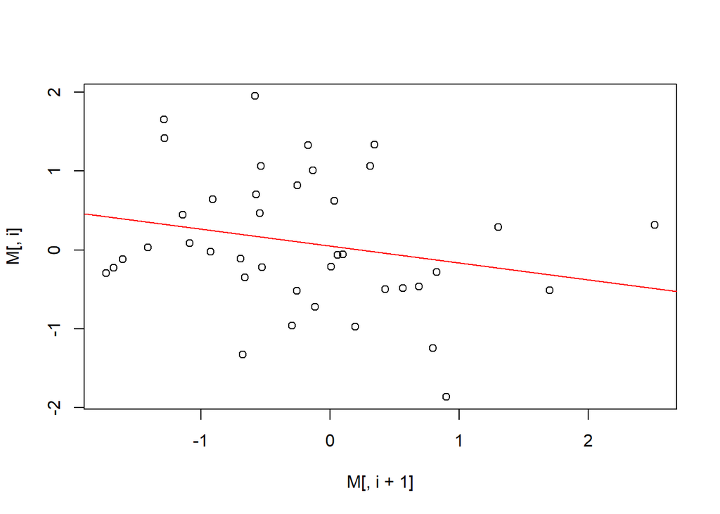

```
##
## Call:
## lm(formula = M[, i] ~ M[, i + 1])
##
## Residuals:
##      Min       1Q   Median       3Q      Max
## -1.33522 -0.52077 -0.01378  0.54976  2.01881
##
## Coefficients:
##             Estimate Std. Error t value Pr(>|t|)
## (Intercept)  -0.2251     0.1390  -1.619   0.1138
## M[, i + 1]   -0.3489     0.1487  -2.346   0.0243 *
## ---
## Signif. codes:  0 '***' 0.001 '**' 0.01 '*' 0.05 '.' 0.1 ' ' 1
##
## Residual standard error: 0.8779 on 38 degrees of freedom
## Multiple R-squared:  0.1265, Adjusted R-squared:  0.1035
## F-statistic: 5.505 on 1 and 38 DF,  p-value: 0.02428
```

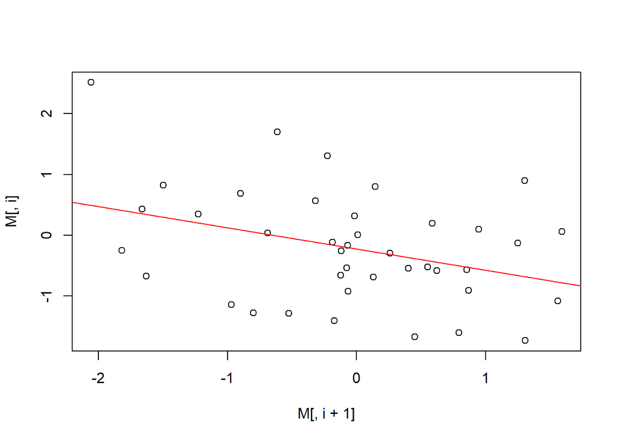

```
##
## Call:
## lm(formula = M[, i] ~ M[, i + 1])
##
## Residuals:
##      Min       1Q   Median       3Q      Max
## -2.12550 -0.48607  0.01578  0.64497  1.78311
##
## Coefficients:
##             Estimate Std. Error t value Pr(>|t|)
## (Intercept)  -0.0681     0.1507  -0.452    0.654
## M[, i + 1]   -0.1155     0.1288  -0.897    0.375
##
## Residual standard error: 0.9478 on 38 degrees of freedom
## Multiple R-squared:  0.02075,    Adjusted R-squared:  -0.005024
## F-statistic: 0.805 on 1 and 38 DF,  p-value: 0.3752
```

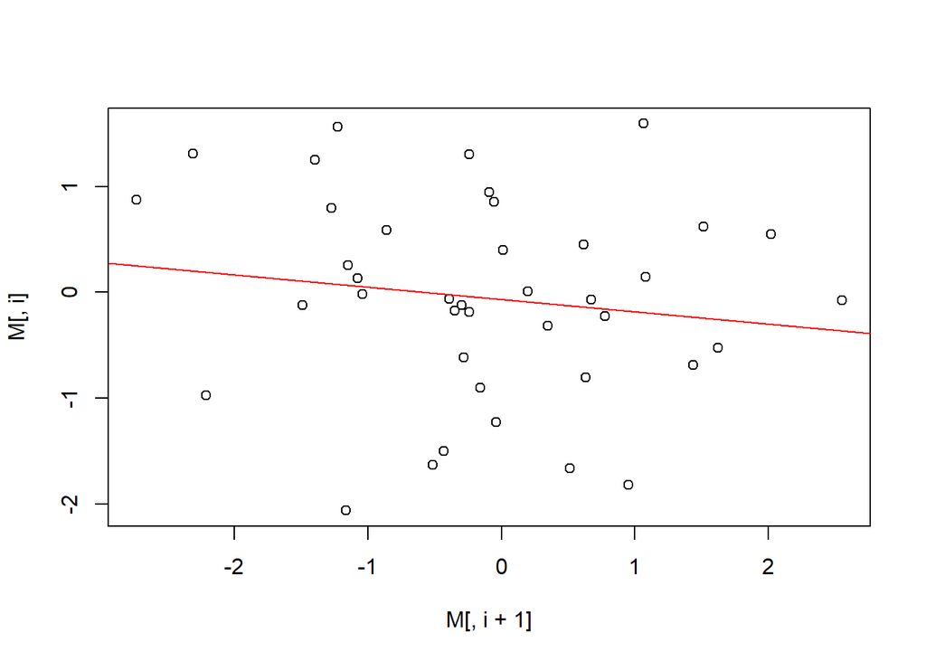

```
##
## Call:
## lm(formula = M[, i] ~ M[, i + 1])
##
## Residuals:
##      Min       1Q   Median       3Q      Max
## -2.72218 -0.84660  0.00586  0.69828  2.42654
##
## Coefficients:
##             Estimate Std. Error t value Pr(>|t|)
## (Intercept) -0.09455    0.18960  -0.499    0.621
## M[, i + 1]   0.17325    0.18293   0.947    0.350
##
## Residual standard error: 1.18 on 38 degrees of freedom
## Multiple R-squared:  0.02306,    Adjusted R-squared:  -0.00265
## F-statistic: 0.8969 on 1 and 38 DF,  p-value: 0.3496
```

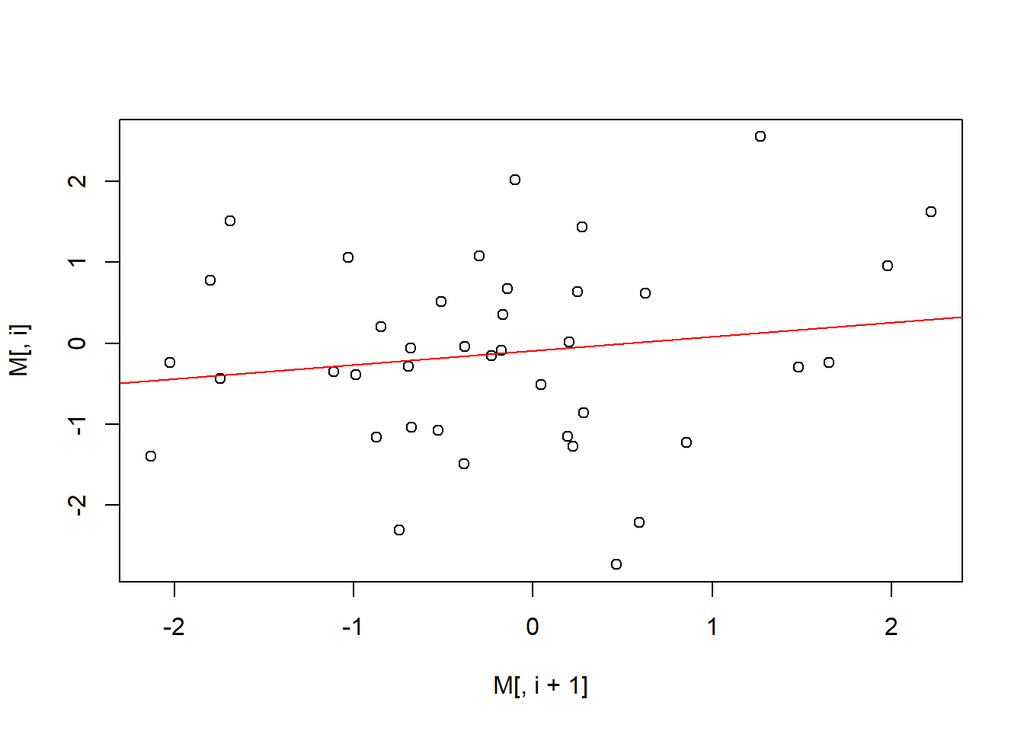

```
##
## Call:
## lm(formula = M[, i] ~ M[, i + 1])
##
## Residuals:
##      Min       1Q   Median       3Q      Max
## -1.92678 -0.58333 -0.01709  0.41787  2.46496
##
## Coefficients:
##             Estimate Std. Error t value Pr(>|t|)
## (Intercept)  -0.1687     0.1665  -1.013    0.317
## M[, i + 1]   -0.1212     0.2003  -0.605    0.549
##
## Residual standard error: 1.042 on 38 degrees of freedom
## Multiple R-squared:  0.009548,   Adjusted R-squared:  -0.01652
## F-statistic: 0.3663 on 1 and 38 DF,  p-value: 0.5486
```

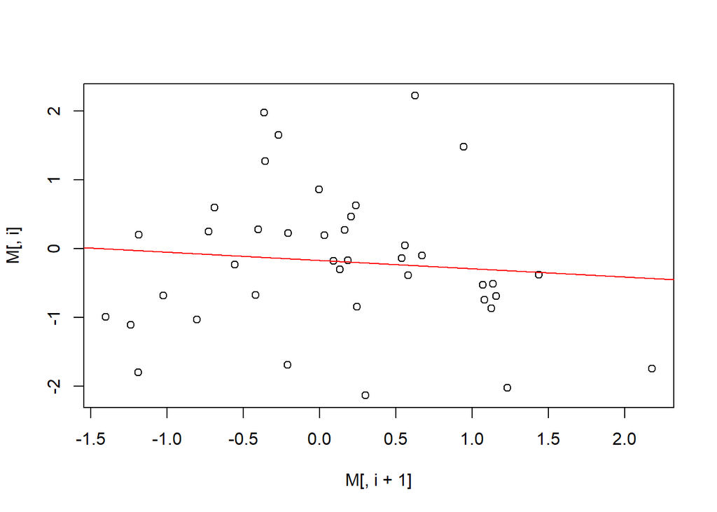

```
##
## Call:
## lm(formula = M[, i] ~ M[, i + 1])
##
## Residuals:
##      Min       1Q   Median       3Q      Max
## -1.48685 -0.52379  0.02509  0.52007  2.06689
##
## Coefficients:
##             Estimate Std. Error t value Pr(>|t|)
## (Intercept)  0.12339    0.13494   0.914    0.366
## M[, i + 1]   0.01851    0.13607   0.136    0.893
##
## Residual standard error: 0.8433 on 38 degrees of freedom
## Multiple R-squared:  0.0004868,  Adjusted R-squared:  -0.02582
## F-statistic: 0.01851 on 1 and 38 DF,  p-value: 0.8925
```

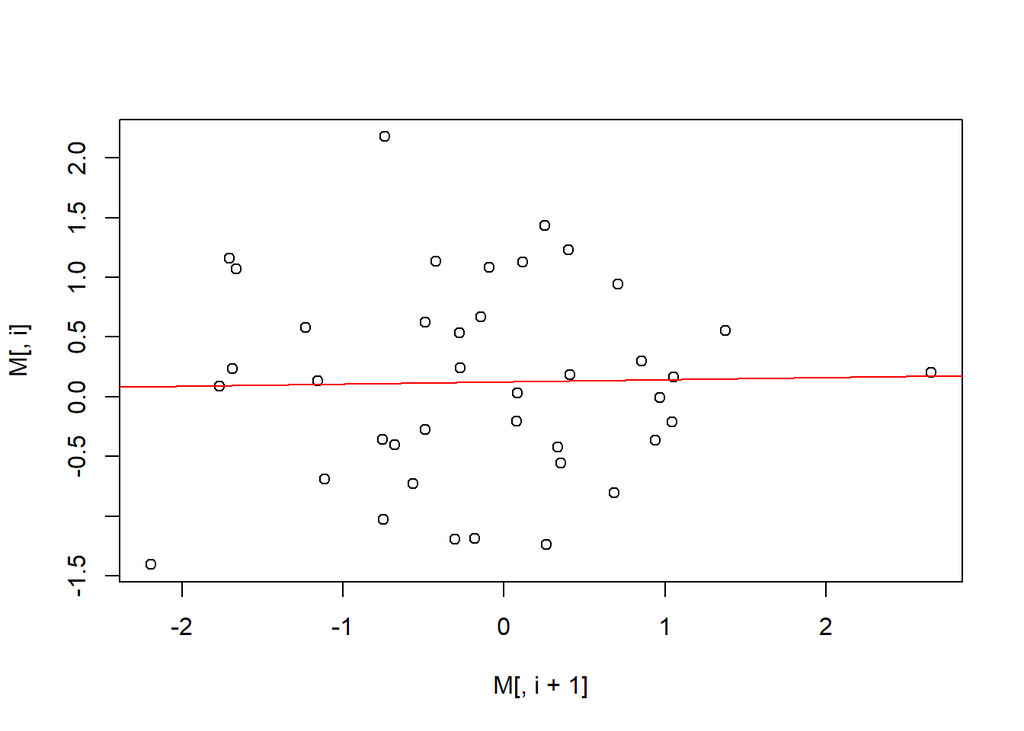

```
##
## Call:
## lm(formula = M[, i] ~ M[, i + 1])
##
## Residuals:
##     Min      1Q  Median      3Q     Max
## -1.9565 -0.5528 -0.0122  0.5654  2.7958
##
## Coefficients:
##             Estimate Std. Error t value Pr(>|t|)
## (Intercept)  -0.1593     0.1603  -0.994    0.327
## M[, i + 1]    0.0568     0.1770   0.321    0.750
##
## Residual standard error: 1.004 on 38 degrees of freedom
## Multiple R-squared:  0.002702,   Adjusted R-squared:  -0.02354
## F-statistic: 0.103 on 1 and 38 DF,  p-value: 0.7501
```

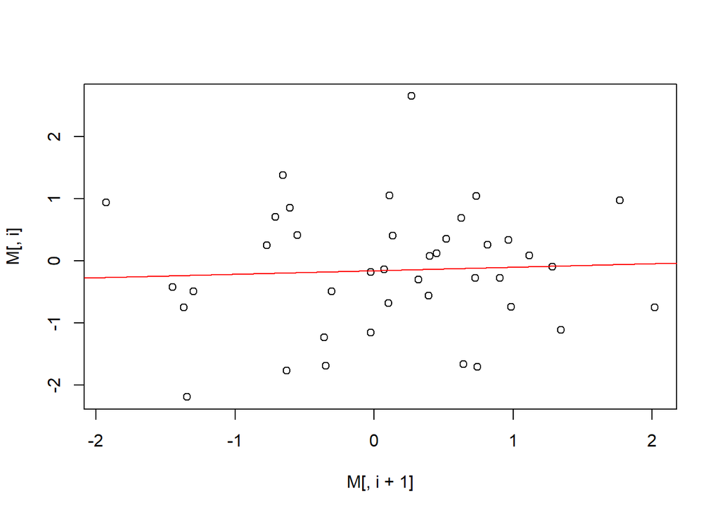

```
##
## Call:
## lm(formula = M[, i] ~ M[, i + 1])
##
## Residuals:
##     Min      1Q  Median      3Q     Max
## -1.8488 -0.6107  0.1048  0.6477  2.0418
##
## Coefficients:
##             Estimate Std. Error t value Pr(>|t|)
## (Intercept)  0.09872    0.14652   0.674    0.505
## M[, i + 1]  -0.15308    0.15625  -0.980    0.333
##
## Residual standard error: 0.9088 on 38 degrees of freedom
## Multiple R-squared:  0.02464,    Adjusted R-squared:  -0.00103
## F-statistic: 0.9599 on 1 and 38 DF,  p-value: 0.3334
```

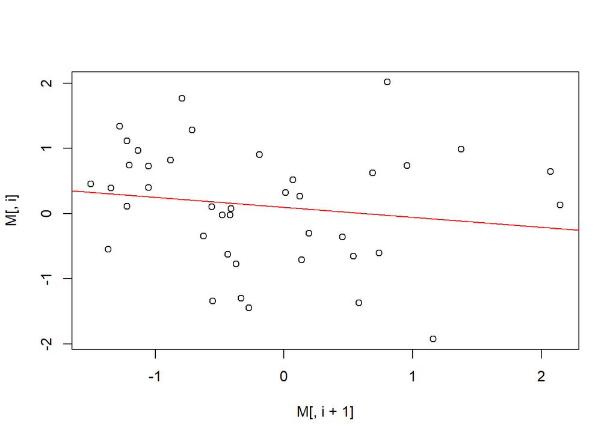

```
##
## Call:
## lm(formula = M[, i] ~ M[, i + 1])
##
## Residuals:
##     Min      1Q  Median      3Q     Max
## -1.3347 -0.7686 -0.2043  0.6420  2.3396
##
## Coefficients:
##             Estimate Std. Error t value Pr(>|t|)
## (Intercept) -0.18491    0.14985  -1.234    0.225
## M[, i + 1]   0.01599    0.15487   0.103    0.918
##
## Residual standard error: 0.9434 on 38 degrees of freedom
## Multiple R-squared:  0.0002804,  Adjusted R-squared:  -0.02603
## F-statistic: 0.01066 on 1 and 38 DF,  p-value: 0.9183
```

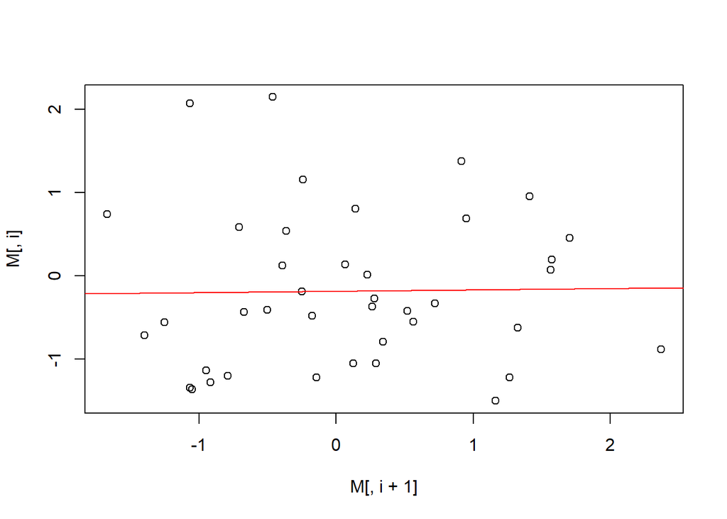

```
##
## Call:
## lm(formula = M[, i] ~ M[, i + 1])
##
## Residuals:
##     Min      1Q  Median      3Q     Max
## -1.8619 -0.7127  0.0368  0.7501  2.1407
##
## Coefficients:
##             Estimate Std. Error t value Pr(>|t|)
## (Intercept)   0.3217     0.1932   1.665    0.104
## M[, i + 1]   -0.2054     0.1097  -1.871    0.069 .
## ---
## Signif. codes:  0 '***' 0.001 '**' 0.01 '*' 0.05 '.' 0.1 ' ' 1
##
## Residual standard error: 0.9456 on 38 degrees of freedom
## Multiple R-squared:  0.08439,    Adjusted R-squared:  0.0603
## F-statistic: 3.502 on 1 and 38 DF,  p-value: 0.06899
```

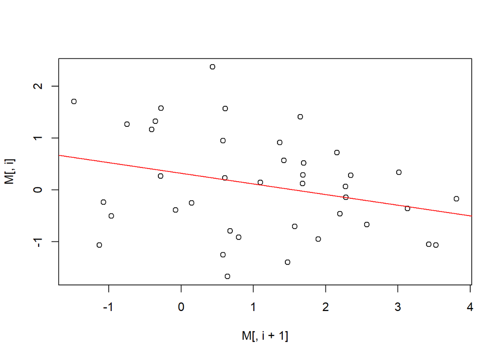

```
##
## Call:
## lm(formula = M[, i] ~ M[, i + 1])
##
## Residuals:
##      Min       1Q   Median       3Q      Max
## -2.19694 -0.74306  0.04019  0.70426  2.16208
##
## Coefficients:
##             Estimate Std. Error t value Pr(>|t|)
## (Intercept)   0.5315     0.2096   2.536   0.0154 *
## M[, i + 1]    0.5244     0.1066   4.918 1.72e-05 ***
## ---
## Signif. codes:  0 '***' 0.001 '**' 0.01 '*' 0.05 '.' 0.1 ' ' 1
##
## Residual standard error: 1.093 on 38 degrees of freedom
## Multiple R-squared:  0.3889, Adjusted R-squared:  0.3728
## F-statistic: 24.18 on 1 and 38 DF,  p-value: 1.716e-05
```

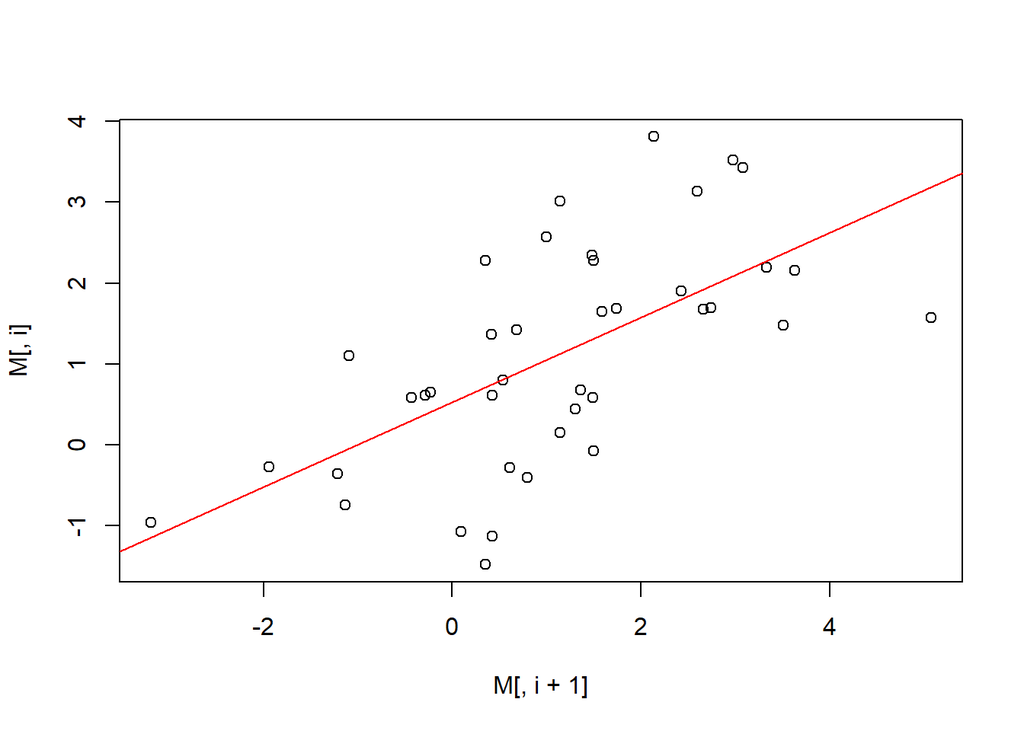

```
##
## Call:
## lm(formula = M[, i] ~ M[, i + 1])
##
## Residuals:
##     Min      1Q  Median      3Q     Max
## -2.4489 -0.8873 -0.2378  0.8379  3.1221
##
## Coefficients:
##             Estimate Std. Error t value Pr(>|t|)
## (Intercept)   0.2789     0.2788   1.000    0.323
## M[, i + 1]    0.7025     0.1535   4.576 4.94e-05 ***
## ---
## Signif. codes:  0 '***' 0.001 '**' 0.01 '*' 0.05 '.' 0.1 ' ' 1
##
## Residual standard error: 1.335 on 38 degrees of freedom
## Multiple R-squared:  0.3553, Adjusted R-squared:  0.3384
## F-statistic: 20.94 on 1 and 38 DF,  p-value: 4.938e-05
```

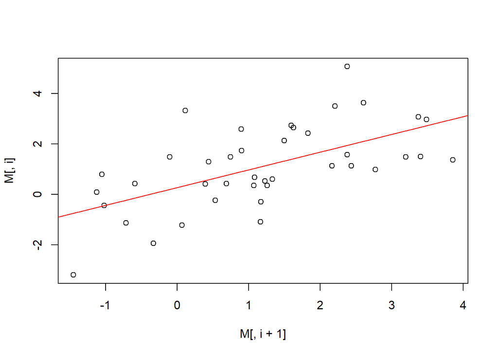

```
##
## Call:
## lm(formula = M[, i] ~ M[, i + 1])
##
## Residuals:
##     Min      1Q  Median      3Q     Max
## -2.8481 -0.6397  0.1940  0.6629  2.0497
##
## Coefficients:
##             Estimate Std. Error t value Pr(>|t|)
## (Intercept)   0.6316     0.2492   2.534   0.0155 *
## M[, i + 1]    0.4869     0.1379   3.532   0.0011 **
## ---
## Signif. codes:  0 '***' 0.001 '**' 0.01 '*' 0.05 '.' 0.1 ' ' 1
##
## Residual standard error: 1.224 on 38 degrees of freedom
## Multiple R-squared:  0.2471, Adjusted R-squared:  0.2273
## F-statistic: 12.47 on 1 and 38 DF,  p-value: 0.001101
```

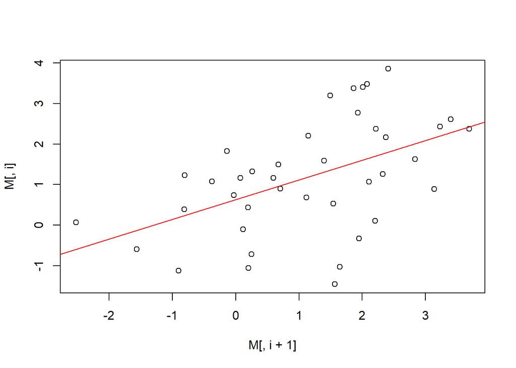

```
##
## Call:
## lm(formula = M[, i] ~ M[, i + 1])
##
## Residuals:
##      Min       1Q   Median       3Q      Max
## -2.33501 -0.64387 -0.02558  0.67949  2.04227
##
## Coefficients:
##             Estimate Std. Error t value Pr(>|t|)
## (Intercept)   0.6397     0.1917   3.336  0.00191 **
## M[, i + 1]    0.6563     0.1183   5.547 2.38e-06 ***
## ---
## Signif. codes:  0 '***' 0.001 '**' 0.01 '*' 0.05 '.' 0.1 ' ' 1
##
## Residual standard error: 1.07 on 38 degrees of freedom
## Multiple R-squared:  0.4474, Adjusted R-squared:  0.4329
## F-statistic: 30.77 on 1 and 38 DF,  p-value: 2.381e-06
```

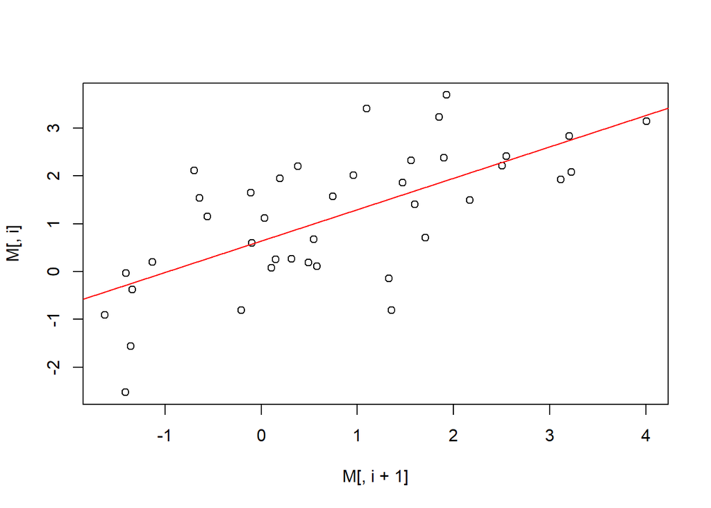

```
##
## Call:
## lm(formula = M[, i] ~ M[, i + 1])
##
## Residuals:
##      Min       1Q   Median       3Q      Max
## -2.33757 -0.75088 -0.03647  0.80114  2.29800
##
## Coefficients:
##             Estimate Std. Error t value Pr(>|t|)
## (Intercept)   0.2212     0.2275   0.972 0.337069
## M[, i + 1]    0.6016     0.1393   4.320 0.000108 ***
## ---
## Signif. codes:  0 '***' 0.001 '**' 0.01 '*' 0.05 '.' 0.1 ' ' 1
##
## Residual standard error: 1.202 on 38 degrees of freedom
## Multiple R-squared:  0.3294, Adjusted R-squared:  0.3117
## F-statistic: 18.66 on 1 and 38 DF,  p-value: 0.000108
```

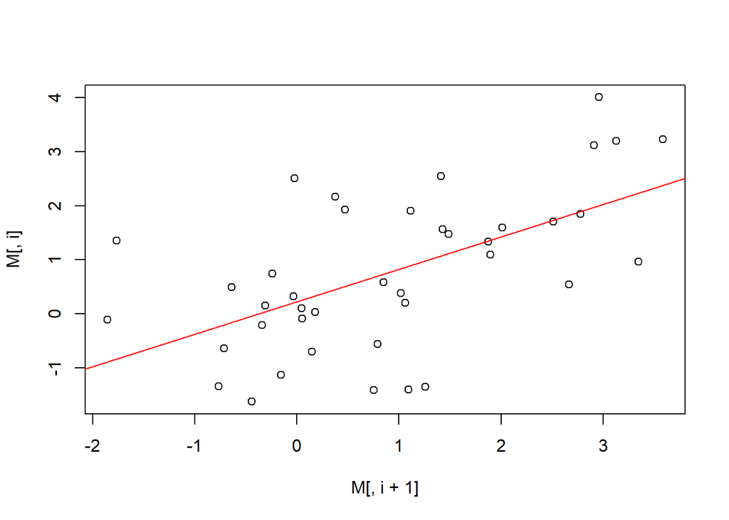

```
##
## Call:
## lm(formula = M[, i] ~ M[, i + 1])
##
## Residuals:
##     Min      1Q  Median      3Q     Max
## -2.9368 -0.6543  0.0396  0.7384  2.0569
##
## Coefficients:
##             Estimate Std. Error t value Pr(>|t|)
## (Intercept)   0.4706     0.2140   2.199 0.034042 *
## M[, i + 1]    0.5183     0.1293   4.009 0.000275 ***
## ---
## Signif. codes:  0 '***' 0.001 '**' 0.01 '*' 0.05 '.' 0.1 ' ' 1
##
## Residual standard error: 1.174 on 38 degrees of freedom
## Multiple R-squared:  0.2973, Adjusted R-squared:  0.2788
## F-statistic: 16.07 on 1 and 38 DF,  p-value: 0.0002747
```

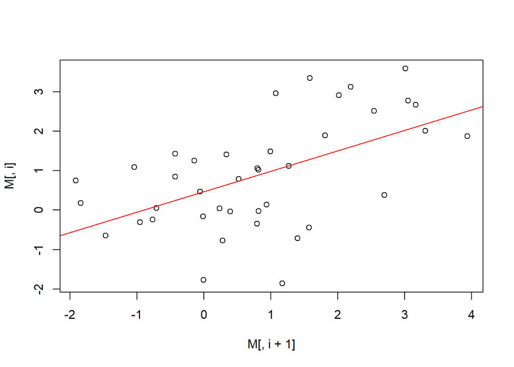

```
##
## Call:
## lm(formula = M[, i] ~ M[, i + 1])
##
## Residuals:
##     Min      1Q  Median      3Q     Max
## -2.6379 -0.8730 -0.3842  0.8637  2.9503
##
## Coefficients:
##             Estimate Std. Error t value Pr(>|t|)
## (Intercept)   0.3981     0.2679   1.486   0.1455
## M[, i + 1]    0.4266     0.1613   2.644   0.0118 *
## ---
## Signif. codes:  0 '***' 0.001 '**' 0.01 '*' 0.05 '.' 0.1 ' ' 1
##
## Residual standard error: 1.353 on 38 degrees of freedom
## Multiple R-squared:  0.1554, Adjusted R-squared:  0.1331
## F-statistic:  6.99 on 1 and 38 DF,  p-value: 0.01184
```

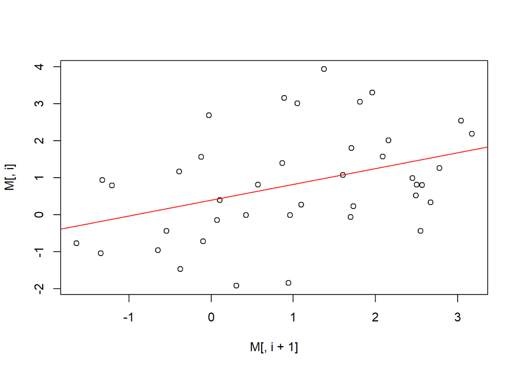

```
##
## Call:
## lm(formula = M[, i] ~ M[, i + 1])
##
## Residuals:
##     Min      1Q  Median      3Q     Max
## -1.9402 -0.8634  0.1130  0.7694  2.5793
##
## Coefficients:
##             Estimate Std. Error t value Pr(>|t|)
## (Intercept)   0.4640     0.2327   1.994 0.053349 .
## M[, i + 1]    0.5228     0.1394   3.750 0.000589 ***
## ---
## Signif. codes:  0 '***' 0.001 '**' 0.01 '*' 0.05 '.' 0.1 ' ' 1
##
## Residual standard error: 1.163 on 38 degrees of freedom
## Multiple R-squared:  0.2701, Adjusted R-squared:  0.2509
## F-statistic: 14.06 on 1 and 38 DF,  p-value: 0.0005887
```